# ARIMA model

Paisan Leewattana

2024-05-06

Auto Regression (AR) P $y_t=\delta+\phi_1y_{t-1}+\phi_2y_{t-2}+\dots + \phi_py_{t-p}+ \epsilon_t$ multiple regression with lagged observations as predictors

Moving Average (MA) q $y_t=\mu+\theta_1\epsilon_{t-1}+\theta_2\epsilon_{t-2}+\dots + \theta_q\epsilon_{t-q}+ \epsilon_t$ multiple regression with lagged errors as predictors.

ARIMA(p,d,q ) $y'_{t} = c + \phi_{1}y'_{t-1} + \cdots + \phi_{p}y'_{t-p} + \theta_{1}\varepsilon_{t-1} + \cdots + \theta_{q}\varepsilon_{t-q} + \varepsilon_{t}$

AR >> yt dependent on yt-1 … MA >> yt dependent on the error terms et et-1 …error terms are random

White noise ARIMA(0,0,0) with no constant >> it is stationary $y_t - y_{t-1} = \varepsilon_te$  
Random walk ARIMA(0,1,0) with no constant $y_t = y_{t-1} + \varepsilon_t$  
Random walk with drift ARIMA(0,1,0) with a constant  
Auto regression ARIMA(p,0,0)  
Moving average ARIMA(0,0,q)

# 1. Install Library

```r
library(readxl)
library(fpp3)
```

```r
library(ggplot2)
library(dplyr)
library(tidyverse)
library(urca)
library(fastmap)
```

# 2. Download Data frame

```r
gdp <- read_excel("F:/Rwork/gdpfc.xlsx",sheet = "GDPy")
print(gdp)
```

```
## # A tibble: 33 × 3
##    index year      GDP
##    <dbl> <chr>   <dbl>
##  1     1 1990  3373479
##  2     2 1991  3656940
##  3     3 1992  3994472
##  4     4 1993  4341027
##  5     5 1994  4688180
##  6     6 1995  5068875
##  7     7 1996  5355365
##  8     8 1997  5207900
##  9     9 1998  4810329
## 10    10 1999  5030271
## # ℹ 23 more rows
```

Create time series and index

```r
gdp$year <- as.integer(gdp$year)
gdp1 <- gdp |> as_tsibble(index = year)
```

# 3. Plot graph

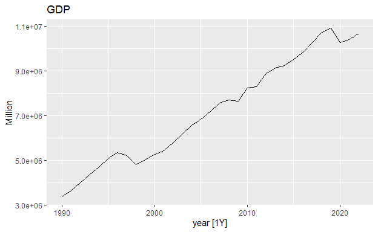

```r
gdp1|> autoplot(GDP)+ labs(title = "GDP", y = "Million")
```

# 4. Stationary

Stationary mean and var is stable. >> white noise >>without trend or seasonality If a time series is stationary, then the autocorrelation of the lags will drop to zero quickly.

Non stationary 2 type 1 deterministic trend 2 Random walk or stochastic trend $y_t = y_{t-1} + \varepsilon_t$ , $\epsilon_t$ is white noise Random walk with drift $y_t =\mu + y_{t-1} + \varepsilon_t$ , $\mu$ is drift (non stationary)

## 4.1 ACF PACF

stationary ACF is 0 quickly  
ACF >> MA(q) lag time of residual of y  
>> Lack of correlation = white noise >> Y not correlation yt-1

PACF >> AR(p) lag p of y

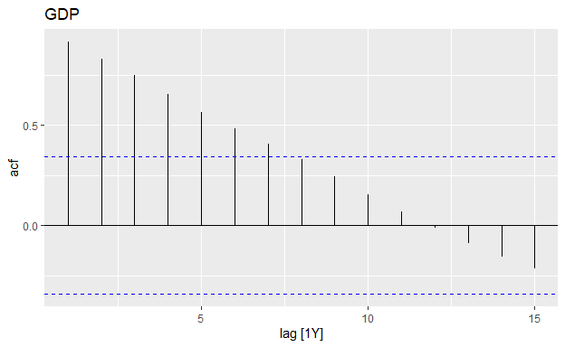

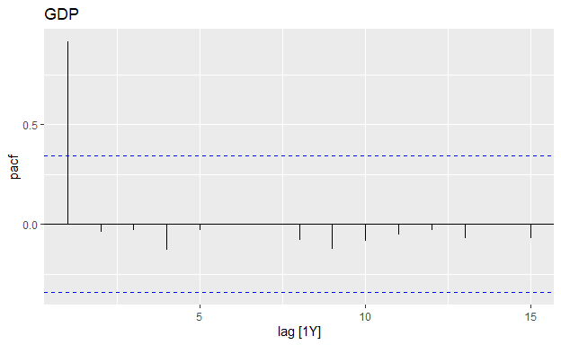

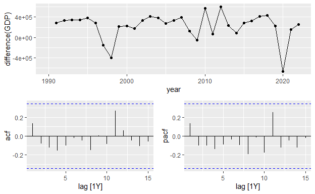

```r
gdp1 |> ACF(GDP) |> autoplot() + labs(title="GDP")
gdp1 |> PACF(GDP) |> autoplot() + labs(title="GDP")
#gdp1 |> ACF(difference(GDP)) |> autoplot() + labs(subtitle = "Differencing GDP")
#gdp1 |> autoplot(difference(GDP))+ labs(title = "GDP Diff", y = "Million")
gdp1 |> gg_tsdisplay(difference(GDP), plot_type='partial')
```

## 4.2 ADF

1. Dickey–Fuller t-statistic test for unit root test Ho :$\phi$=1 Non stationary,random walk , unit root  
   H1 :$\phi$< 1 reject Ho y is stationary

   package urca ur.df(x, type=(“trend”) , lags= 1 or selectlages= c(“AIC”) > trend and lag
2. Augmented Dickey Fuller Unit root test Ho : $\pi$ = 0 ,Non stationary p-value <= .05 reject Ho data is stationary

use the adf.test() function from the tseries library.

library(tseries) gdp1 |> mutate(diff_GDP = difference(GDP)) |> adf.test(diff_GDP)

## 4.3 Ljung box Test fit

it is applied to the residuals of a fitted ARIMA model, not the original series. Test residuals from the ARIMA model have no autocorrelation ARIMA(p,0,q) model, df = ℎ−𝑝−𝑞

Ho : $\rho$k = 0 ,No autocorrelation

Q = n(n+2) Σpk2 / (n-k)  
pk = sample autocorrelation at lag k  
n =sample size  
H0:The residuals are independently distributed (No autocorrelation)

p-value > 0.05: →Accept Ho residual No autocorrelation Model fit a non-stationary signal will have a low p-value

data change random > uncorelate with previous time

Box.test(x, lag =1, type=c(“Box-Pierce”, “Ljung-Box”), fitdf = 0)

x: A numeric vector or univariate time series  
lag: Specified number of lags  
type: Test to be performed; options include Box-Pierce and Ljung-Box  
fitdf: bDegrees of freedom to be subtracted if x is a series of residuals

```r
gdp1 |> mutate(diff_GDP = difference(GDP)) |> features(diff_GDP, ljung_box, lag=1)
```

| lb_stat | lb_pvalue |
| --- | --- |
| 0.6383004 | 0.4243269 |

## 4.4 KPSS

Kwiatkowski-Phillips-Schmidt-Shin for level or trend stationarity a low p-value will indicate a signal that is not trend stationary, has a unit root

## 4.5 Transform

Differencing $\Delta yt = \mu + \varepsilon_t$

# 5. Select Model

```r
# Non-seasonal ARIMA Model
fit1 <- gdp1 |> model(ARIMA(GDP))
report(fit1)
```

```
## Series: GDP
## Model: ARIMA(0,1,0) w/ drift
##
## Coefficients:
##        constant
##       228209.47
## s.e.   44141.37
##
## sigma^2 estimated as 6.436e+10:  log likelihood=-443.1
## AIC=890.21   AICc=890.62   BIC=893.14
```

```r
# Test
fit2 <- gdp1 |> model(arima010 = ARIMA(GDP ~ pdq(0,1,0)),
        stepwise = ARIMA(GDP),
        search = ARIMA(GDP, stepwise=FALSE))
report(fit2)
```

| .model | sigma2 | log_lik | AIC | AICc | BIC | ar_roots | ma_roots |
| --- | --- | --- | --- | --- | --- | --- | --- |
| arima010 | 64364302511 | -443.1032 | 890.2063 | 890.6201 | 893.1378 |  |  |
| stepwise | 64364302511 | -443.1032 | 890.2063 | 890.6201 | 893.1378 |  |  |
| search | 64364302511 | -443.1032 | 890.2063 | 890.6201 | 893.1378 |  |  |

# 6. Forecasting

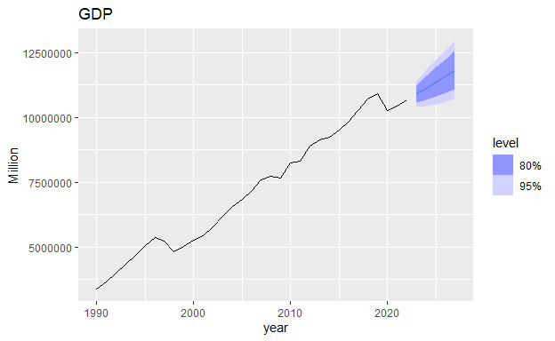

```r
fit1 |> forecast(h=5) |>autoplot(gdp1) + labs(y = "Million", title = "GDP")
```

# 7. Residual Diagnostics

bind_rows( `Regression residuals` = as_tibble(residuals(fit, type = “regression”)), `ARIMA residuals` = as_tibble(residuals(fit, type = “innovation”)), .id = “type” ) |> mutate( type = factor(type, levels=c( “Regression residuals”, “ARIMA residuals”)) ) |> ggplot(aes(x = Year, y = .resid)) + geom_line() + facet_grid(vars(type))

fit |> gg_tsresiduals()

augment(fit) |> features(.innov, ljung_box, dof = 2, lag = 10)

```
 #gdp1 |>   model(NAIVE(GDP)) |>   gg_tsresiduals()
```

# 8. Time series cross-validation

train

```r
#train <-gdp1 |> filter(year =< 2020 )
#test <- gdp1 |> filter(year > 2020 )
```